# Kaggle Desafiío de Regresion

ca.sanchez1209

May 15, 2015

```r
library(lubridate, quietly = TRUE)
library(dplyr, quietly = TRUE)
```

```r
library(tidyr, quietly = TRUE)
library(ggplot2, quietly = TRUE)
library(caret, quietly = TRUE)
```

```r
training <- read.csv("~/Desktop/training_set.csv",header=T)

testing <- read.csv("~/Desktop/test_set.csv",header=T)
```

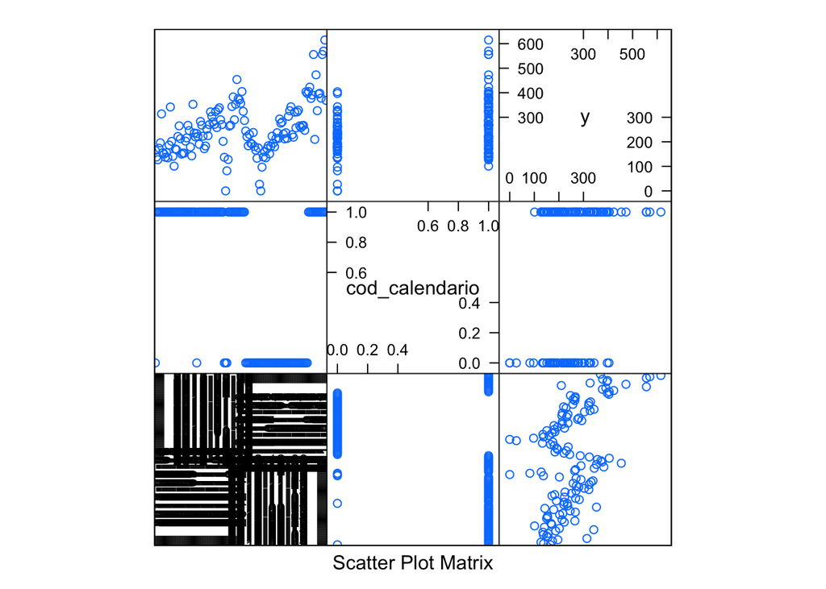

```r
featurePlot(x = training[, 1:2],
            y = training$conteo_ordenes,
            plot = "pairs",auto.key = list(columns = 3))
```

Aqui podemos ver las variables codigo calendario y fecha, vemos que existe una tendencia “ondulada” con la fecha, sin embargo el codigo del calendario no es muy informativo, sobretodo sin saber que significa este.

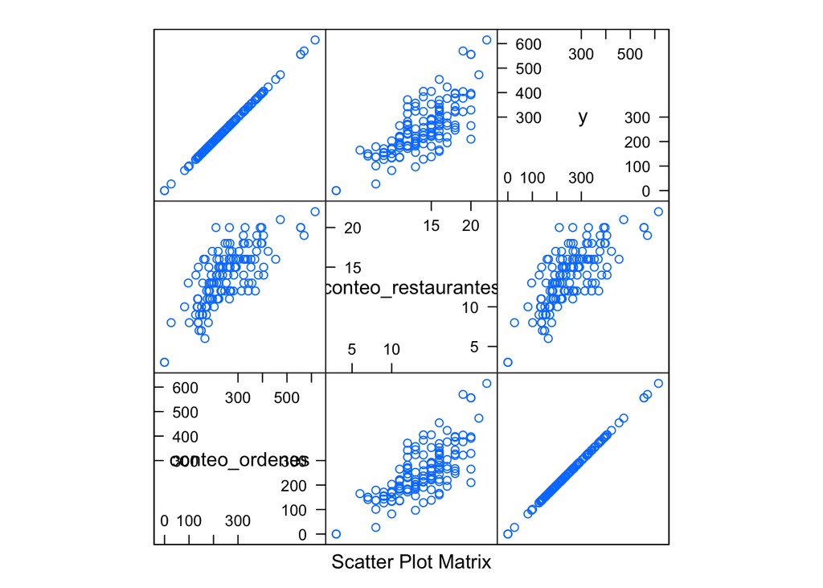

```r
featurePlot(x = training[, 3:4],
            y = training$conteo_ordenes,
            plot = "pairs",auto.key = list(columns = 3))
```

Aqui podemos ver una tendencia creciente con la variable de conteo de restaurantes.

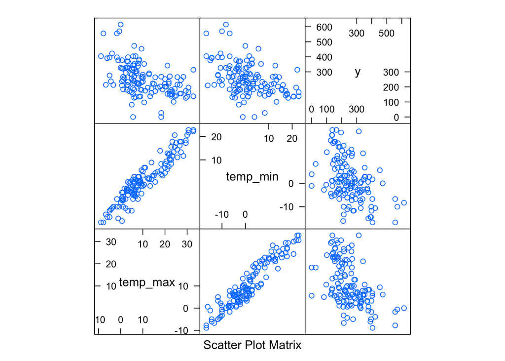

```r
featurePlot(x = training[, 5:6],
            y = training$conteo_ordenes,
            plot = "pairs",auto.key = list(columns = 3))
```

Las temperaturas tambien parecen tener cierta tendencia, sin embargo esta vez decreciente.

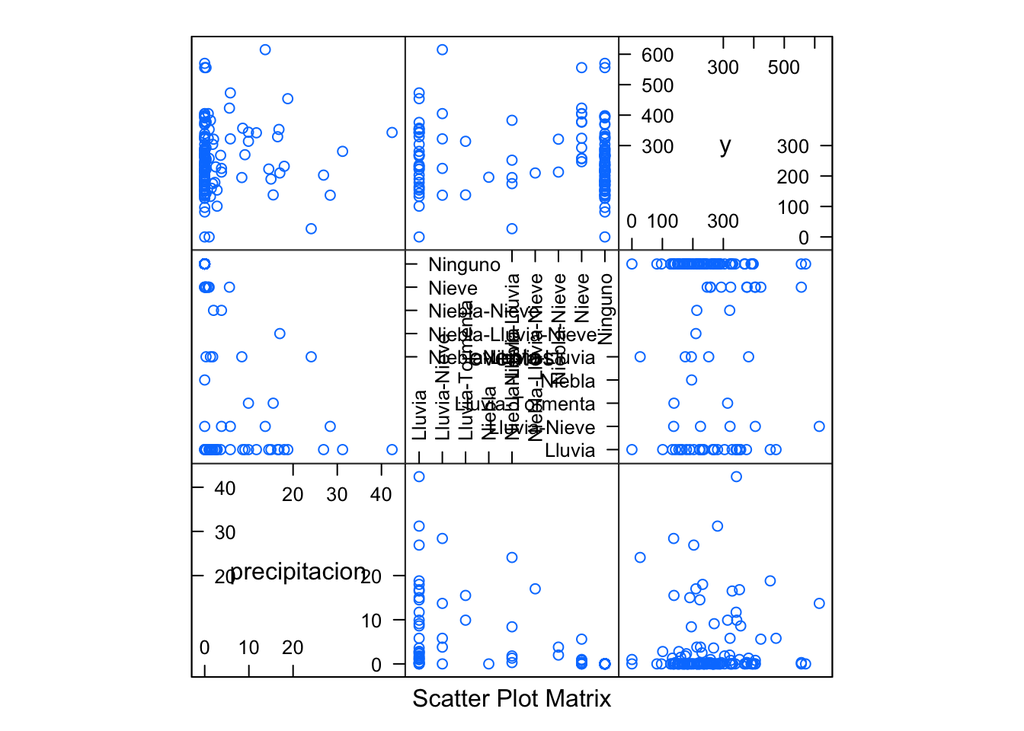

```r
featurePlot(x = training[, 7:8],
            y = training$conteo_ordenes,
            plot = "pairs",auto.key = list(columns = 3))
```

Por la forma de la grafica parece que la variable de precipitacion no es muy informativa, sin embargo puede deberse a que los datos son de una zona donde llueve poco, de la misma manera con los eventos, los mas comunes son o lluvia o ninguno.

La estacion del año en la que se encuentra, el tipo de ciudad en la que se encuentra, orientado hacia la cantidad de personas en ella, y la edad de las mismas, el costo total de las ordenes del dia y un calendario de eventos deportivos televisados, entre otras variables tambien podrían ser informativos.

```r
results <- read.csv("~/Desktop/result.csv",header=T)
results$DiaSemana <-  wday(results$fecha, label=TRUE)
training$DiaSemana <-  wday(training$fecha, label=TRUE)
summary(training)
```

```
##         fecha     cod_calendario   conteo_ordenes conteo_restaurantes
##  2012-09-01:  1   Min.   :0.0000   Min.   :  0    Min.   : 3.00
##  2012-09-02:  1   1st Qu.:0.0000   1st Qu.:180    1st Qu.:11.00
##  2012-09-03:  1   Median :1.0000   Median :236    Median :14.00
##  2012-09-04:  1   Mean   :0.5985   Mean   :252    Mean   :13.73
##  2012-09-05:  1   3rd Qu.:1.0000   3rd Qu.:322    3rd Qu.:16.00
##  2012-09-06:  1   Max.   :1.0000   Max.   :615    Max.   :22.00
##  (Other)   :131
##     temp_max        temp_min       precipitacion               eventos
##  Min.   :-8.90   Min.   :-16.700   Min.   : 0.000   Ninguno        :80
##  1st Qu.: 3.30   1st Qu.: -4.400   1st Qu.: 0.000   Lluvia         :30
##  Median : 7.80   Median :  0.600   Median : 0.000   Nieve          :11
##  Mean   :10.56   Mean   :  1.466   Mean   : 3.007   Lluvia-Nieve   : 5
##  3rd Qu.:18.90   3rd Qu.:  6.700   3rd Qu.: 1.300   Niebla-Lluvia  : 5
##  Max.   :32.80   Max.   : 22.800   Max.   :42.400   Lluvia-Tormenta: 2
##                                                     (Other)        : 4
##  DiaSemana
##  Sun  :20
##  Mon  :19
##  Tues :19
##  Wed  :19
##  Thurs:20
##  Fri  :19
##  Sat  :21
```

```r
summary(results)
```

```
##         fecha    conteo_ordenes  DiaSemana
##  2012-10-01: 1   Min.   :168.5   Sun  :6
##  2012-10-02: 1   1st Qu.:234.1   Mon  :7
##  2012-10-03: 1   Median :263.3   Tues :7
##  2012-10-04: 1   Mean   :274.1   Wed  :7
##  2012-10-05: 1   3rd Qu.:298.3   Thurs:6
##  2012-10-06: 1   Max.   :462.7   Fri  :7
##  (Other)   :40                   Sat  :6
```